# PracticaSpam

DavidVelasco

2023-01-25

En la detección de Spam se utilizan con frecuencia técnicas de machine learning para mejorar los índices de detección de correos no deseados. En el dataset adjunto, se han seleccionado para cada mensaje una serie de términos clave que suelen aparecer con frecuencia en los mensajes spam. Posteriormente, se ha realizado una codificación vectorial de los correos electrónicos considerando esos términos clave. Para cada correo disponemos de la clasificación por parte de los expertos humanos. Se pide realizar las siguientes tareas:

- Apartado 1) Sustituir un 2% de valores de la matriz de datos por NAs, de manera aleatoria. Imputar dichos valores faltantes y justificar la elección del método utilizado.(1 punto)
- Apartado 2) Realizar un análisis exploratorio de la matriz de datos. Comentar los resultados y utilizar visualizaciones cuando sea necesario. (2 puntos)
- Apartado 3) Eliminar aquellas palabras que tengan una correlación elevada con otras. Calcular el número de documentos en que aparece cada palabra y eliminar aquellas de menor frecuencia. Dibujar un histograma de dichas frecuencias calculadas. Nota: Con la codificación “bag of words” utilizada, el número de documentos en que aparece una palabra se obtiene sumando para cada variable todas las filas. (2 puntos)
- Apartado 4) Proyectar los datos sobre un subespacio de dimensión menor utilizando PCA. ¿ Cuántas componentes principales se deben utilizar para poder visualizar la estructura semántica de los documentos ? Obtener un plot utilizando dichas compoentes principales y comentar si hay estructura de grupo.(2 puntos)
- Apartado 5) Realizar un clustering de los mensajes de spam atendiendo a su contenido semántico. Discutir y comparar el resultado para dos algoritmos diferentes.(2 puntos)
- Apartado 6) Aplicar los mapas autoorganizativos para visualizar la estructura semántica de la colección de documentos utilizada. ¿ Qué ventajas tienen los mapas autoorganizativos con respecto a los algoritmos de clustering utilizados anteriormente ? (1 punto)

```r
#Comprobación de que está el *.csv en el directorio

currentDir <- getwd()
list.files(path="../datos")
```

```
##  [1] "anemonefish.xls"          "beer2.csv"
##  [3] "DatasetLimpio.xlsx"       "EXAMPLE_DataToClean.xlsx"
##  [5] "nombre_variables.txt"     "output"
##  [7] "religions.csv"            "spam.csv"
##  [9] "spam.xls"                 "student-mat.csv"
## [11] "student-por.csv"          "student.zip"
```

```r
if (!file.exists("../datos"))
{stop(paste0("Se necesita que el directorio datos esté en: ",currentDir))}


ComprobarInputs <- function(path, dir,file)
{if (!file.exists(paste0(path,"/",dir)))
{stop(paste0("Se necesita que el directorio ", dir, " esté en: ",path))}
  else if (!file.exists(paste0(path, "/",dir,"/", file)))
    {stop(paste0("Se necesita que ", file," esté en: ", path, "/", dir))}}

parentPath <- dirname(currentDir)

try(ComprobarInputs(parentPath,"datos", "spam.xls"), FALSE)

##Unificacion de los dos ficheros en un dataframe

#Cargo el xls y separo mediante un espacio los registros
dtDatos=read.table("../datos/spam.xls",sep=" ",header=FALSE)

#Cargo los valores del fichero nombre_variables que serán el nombre de las columnas
dtCabeceraFilas=read_fwf("../datos/nombre_variables.txt",show_col_types = FALSE)

#Superpongo las datos de las filas por columnas
dtCabeceraColumnas <- as.data.frame(t(dtCabeceraFilas))

#Unifico las dos tablas copiando la fila 1 en las cabecera del dataset final
names(dtDatos)<- dtCabeceraColumnas[1,]
```

```r
  #Apartado 1)

  #Nrow= 4601 y ncol=58
  #nValores a sustituir=4601*58*0,02

  constante = 0.02
  filas<-nrow(dtDatos)
  columnas<-ncol(dtDatos)-1 #Borro 1 para no poner NA en la ultima columna
  nvalores <- ceiling( filas* (columnas+1)  * constante)
  #Hay 5338 NA en la matriz

  #Duplico el dataframe para hacer este apartado
  dtDatosNA<-dtDatos

  #Pasos y justificación
  #---------------------

  #1. Recorro mediante un while hasta completar el 2% de los valores del dataframe
  #2. Obtengo un valor aleatorio entre 1 y el numero de filas y entre 1 y el numero de columnas
  #3. Compruebo si en esa celda hay un NA.
  #3.1 Si es un NA reiniciamos la iteración del bucle
  #3.2 Si no hay NA, seteamos el NA en esa celda e iteramos el bucle

  #Nota: La funcion sample(x:y,1) obtiene un(1) nº aleatorio entre 'x' e 'y'
  i=1
  while(i<=nvalores){
    valorfila <-sample(1:filas,1)
    valorcol<-sample(1:columnas,1)

    if(is.na(dtDatosNA[valorfila,valorcol])){
    }else{
      dtDatosNA[valorfila,valorcol]=NA
      i<-i+1
    }
  }
  #Compruebo que tengo los 5338 valores en dtDatosNa
  valoresNA <-sum(is.na(dtDatosNA))
  cat(paste("Total valores NA en el dataframe dtDatosNA: ", valoresNA,sep=" "))
```

```
## Total valores NA en el dataframe dtDatosNA:  5338
```

```r
  #Comprobación por columnas
  data.frame(lapply( lapply( dtDatosNA,is.na),sum))
```

| make | address | all | X3d | our | over | remove | internet | order | mail | receive | will | people | report | addresses | free | business | email | you | credit | your | font | X000 | money | hp | hpl | george | X650 | lab | labs | … |
| --- | --- | --- | --- | --- | --- | --- | --- | --- | --- | --- | --- | --- | --- | --- | --- | --- | --- | --- | --- | --- | --- | --- | --- | --- | --- | --- | --- | --- | --- | --- |
| 98 | 88 | 85 | 83 | 120 | 83 | 88 | 87 | 89 | 91 | 89 | 88 | 85 | 88 | 113 | 94 | 98 | 91 | 89 | 97 | 97 | 92 | 83 | 89 | 126 | 99 | 70 | 105 | 73 | 94 | … |

```r
  #Ultimo paso: Donde hay NA sustituir valores y justificar el metodo
  #El metodo elegido es na_interpolation de biblioteca imputeTS
  #Es utili cuando los valores NA estan distribuidos de forma aleatoria y se desea
  #mantener la tendencia general de los datos

  library(imputeTS)
  dtDatosFilled<-na_interpolation(dtDatosNA)

  #Compruebo que no tengo ningun valor NA
  valoresNAfil <-sum(is.na(dtDatosFilled))
  cat(paste("Total valores NA en el dataframe dtDatosFilled: ", valoresNAfil,sep=" "))
```

```
## Total valores NA en el dataframe dtDatosFilled:  0
```

```r
  #Apartado 2)

  #Destacar que la ultima columna es la que confirma si es o no spam el correo

  dim(dtDatosFilled)  #Filas(emails) y columnas(variables)
```

```
## [1] 4601   58
```

```r
  summary(dtDatosFilled)   #Resumen del dataset
```

```
##       make           address             all               3d
##  Min.   :0.0000   Min.   : 0.0000   Min.   :0.0000   Min.   : 0.00000
##  1st Qu.:0.0000   1st Qu.: 0.0000   1st Qu.:0.0000   1st Qu.: 0.00000
##  Median :0.0000   Median : 0.0000   Median :0.0000   Median : 0.00000
##  Mean   :0.1034   Mean   : 0.2126   Mean   :0.2801   Mean   : 0.05811
##  3rd Qu.:0.0000   3rd Qu.: 0.0000   3rd Qu.:0.4200   3rd Qu.: 0.00000
##  Max.   :4.5400   Max.   :14.2800   Max.   :5.1000   Max.   :42.81000
##       our              over             remove          internet
##  Min.   : 0.000   Min.   :0.00000   Min.   :0.0000   Min.   : 0.0000
##  1st Qu.: 0.000   1st Qu.:0.00000   1st Qu.:0.0000   1st Qu.: 0.0000
##  Median : 0.000   Median :0.00000   Median :0.0000   Median : 0.0000
##  Mean   : 0.316   Mean   :0.09479   Mean   :0.1157   Mean   : 0.1057
##  3rd Qu.: 0.390   3rd Qu.:0.00000   3rd Qu.:0.0000   3rd Qu.: 0.0000
##  Max.   :10.000   Max.   :3.57000   Max.   :7.2700   Max.   :11.1100
##      order              mail            receive             will
##  Min.   :0.00000   Min.   : 0.0000   Min.   :0.00000   Min.   :0.0000
##  1st Qu.:0.00000   1st Qu.: 0.0000   1st Qu.:0.00000   1st Qu.:0.0000
##  Median :0.00000   Median : 0.0000   Median :0.00000   Median :0.1300
##  Mean   :0.09048   Mean   : 0.2382   Mean   :0.06063   Mean   :0.5429
##  3rd Qu.:0.00000   3rd Qu.: 0.1700   3rd Qu.:0.00000   3rd Qu.:0.8000
##  Max.   :5.26000   Max.   :18.1800   Max.   :2.61000   Max.   :9.6700
##      people           report           addresses            free
##  Min.   :0.0000   Min.   : 0.00000   Min.   :0.00000   Min.   : 0.0000
##  1st Qu.:0.0000   1st Qu.: 0.00000   1st Qu.:0.00000   1st Qu.: 0.0000
##  Median :0.0000   Median : 0.00000   Median :0.00000   Median : 0.0000
##  Mean   :0.0937   Mean   : 0.05704   Mean   :0.04882   Mean   : 0.2488
##  3rd Qu.:0.0000   3rd Qu.: 0.00000   3rd Qu.:0.00000   3rd Qu.: 0.1100
##  Max.   :5.5500   Max.   :10.00000   Max.   :4.41000   Max.   :20.0000
##     business          email             you             credit
##  Min.   :0.0000   Min.   :0.0000   Min.   : 0.000   Min.   : 0.00000
##  1st Qu.:0.0000   1st Qu.:0.0000   1st Qu.: 0.000   1st Qu.: 0.00000
##  Median :0.0000   Median :0.0000   Median : 1.310   Median : 0.00000
##  Mean   :0.1418   Mean   :0.1837   Mean   : 1.654   Mean   : 0.08575
##  3rd Qu.:0.0000   3rd Qu.:0.0000   3rd Qu.: 2.630   3rd Qu.: 0.00000
##  Max.   :7.1400   Max.   :9.0900   Max.   :18.750   Max.   :18.18000
##       your              font             000             money
##  Min.   : 0.0000   Min.   : 0.000   Min.   :0.0000   Min.   : 0.00000
##  1st Qu.: 0.0000   1st Qu.: 0.000   1st Qu.:0.0000   1st Qu.: 0.00000
##  Median : 0.2400   Median : 0.000   Median :0.0000   Median : 0.00000
##  Mean   : 0.8133   Mean   : 0.118   Mean   :0.1018   Mean   : 0.09369
```

[output cut: 50 more lines]

```
##  Max.   :4.3850   Max.   :9.7520   Max.   :4.08100   Max.   :32.4780
##        $                 #           cap_run_length_average
##  Min.   :0.00000   Min.   : 0.0000   Min.   :   1.000
##  1st Qu.:0.00000   1st Qu.: 0.0000   1st Qu.:   1.592
##  Median :0.00000   Median : 0.0000   Median :   2.276
##  Mean   :0.07641   Mean   : 0.0445   Mean   :   5.186
##  3rd Qu.:0.05400   3rd Qu.: 0.0000   3rd Qu.:   3.700
##  Max.   :6.00300   Max.   :19.8290   Max.   :1102.500
##  cap_run_length_longest cap_run_length_total     clase
##  Min.   :   1.00        Min.   :    1.0      Min.   :0.000
##  1st Qu.:   6.00        1st Qu.:   35.0      1st Qu.:0.000
##  Median :  15.00        Median :   95.0      Median :0.000
##  Mean   :  52.19        Mean   :  282.7      Mean   :0.394
##  3rd Qu.:  43.00        3rd Qu.:  271.5      3rd Qu.:1.000
##  Max.   :9989.00        Max.   :15841.0      Max.   :1.000
```

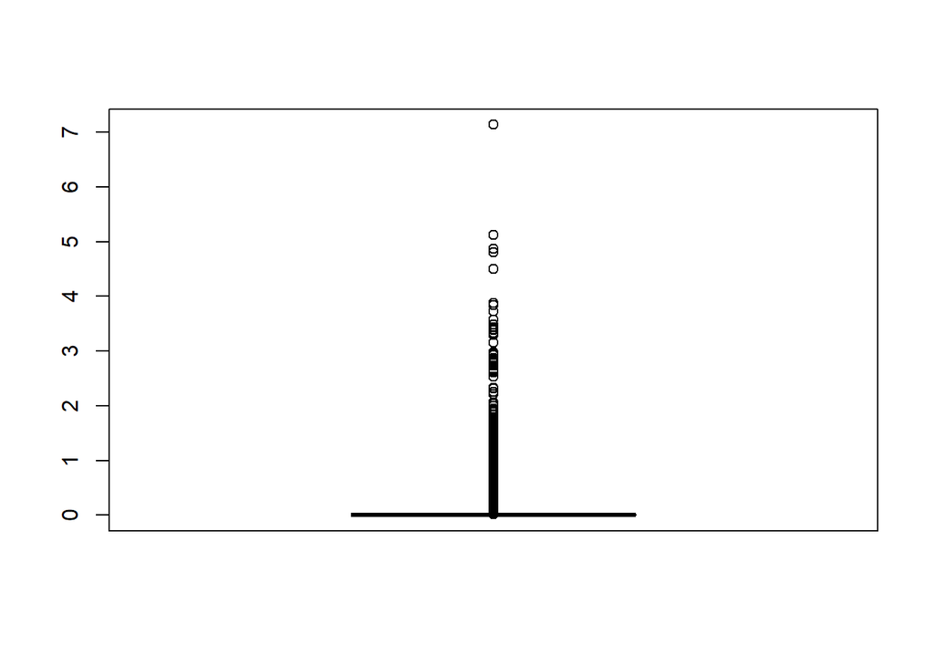

```r
  #Visualizacion

  #Vamos a comprobar por ejemplo si business/free/you siguen una distribucio normal
  boxplot(dtDatosFilled$business)
```

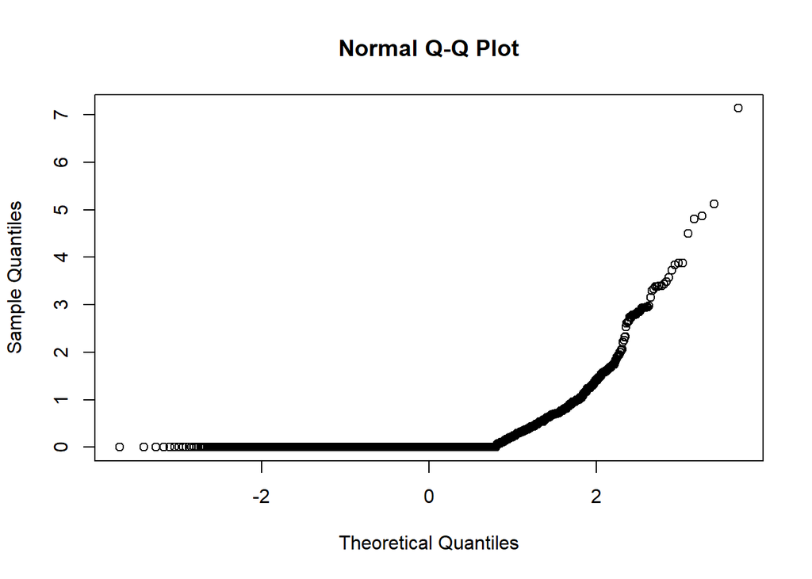

```r
  qqnorm(dtDatosFilled$business)
```

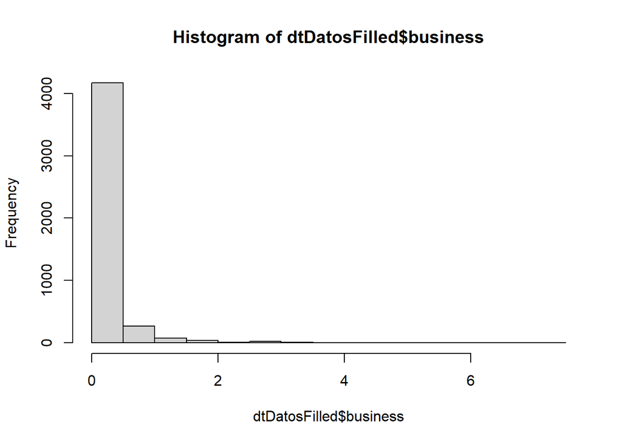

```r
  hist(dtDatosFilled$business)
```

```r
  shapiro.test(dtDatosFilled$business)
```

```
##
##  Shapiro-Wilk normality test
##
## data:  dtDatosFilled$business
## W = 0.36716, p-value < 2.2e-16
```

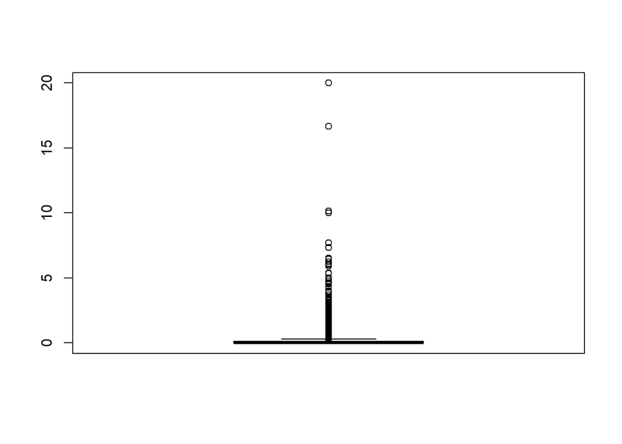

```r
  boxplot(dtDatosFilled$free)
```

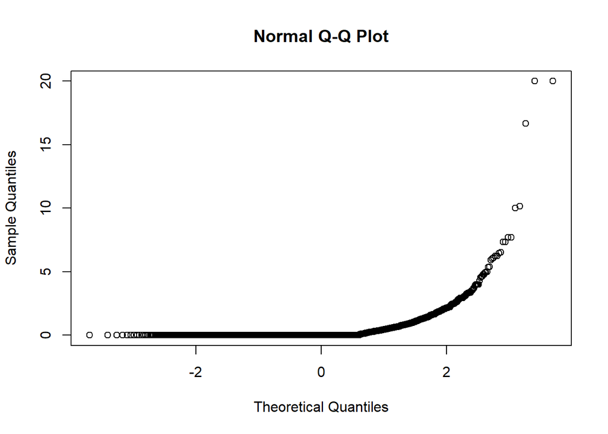

```r
  qqnorm(dtDatosFilled$free)
```

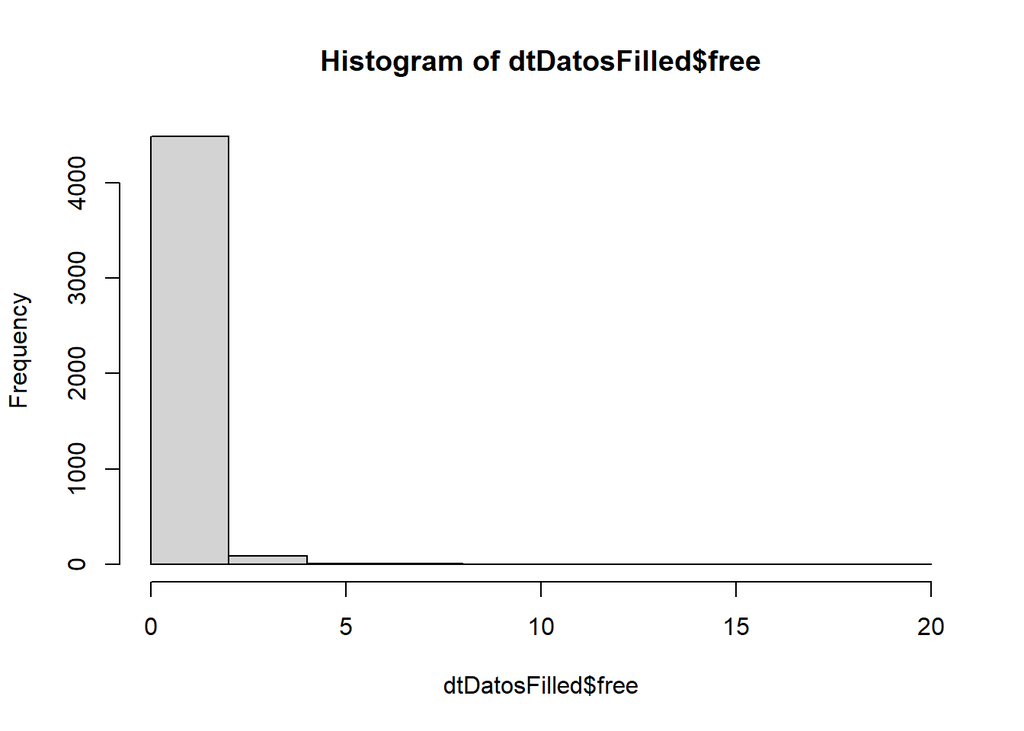

```r
  hist(dtDatosFilled$free)
```

```r
  shapiro.test(dtDatosFilled$free)
```

```
##
##  Shapiro-Wilk normality test
##
## data:  dtDatosFilled$free
## W = 0.30914, p-value < 2.2e-16
```

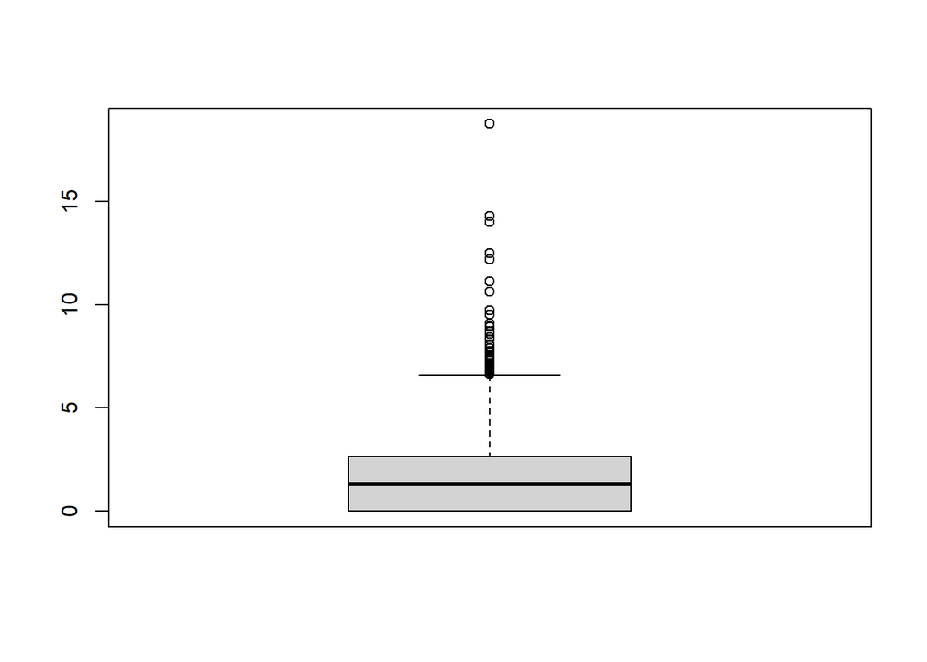

```r
  boxplot(dtDatosFilled$you)
```

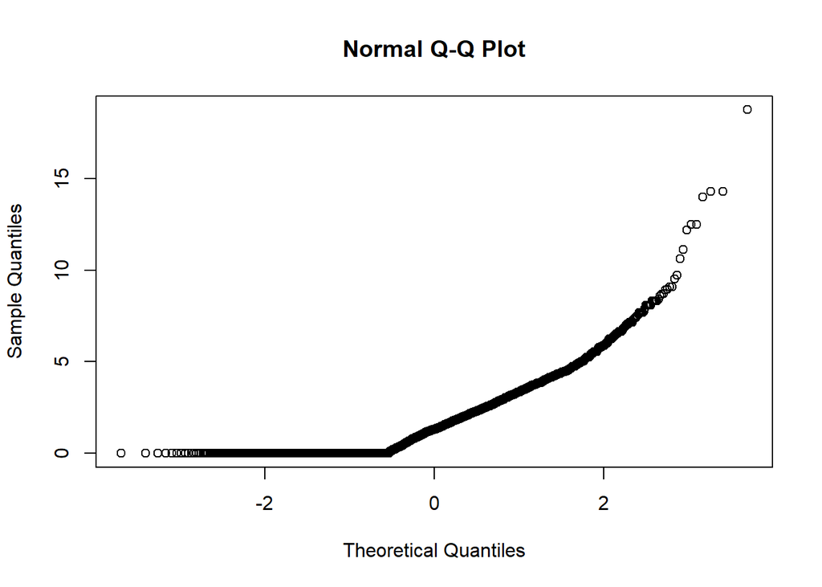

```r
  qqnorm(dtDatosFilled$you)
```

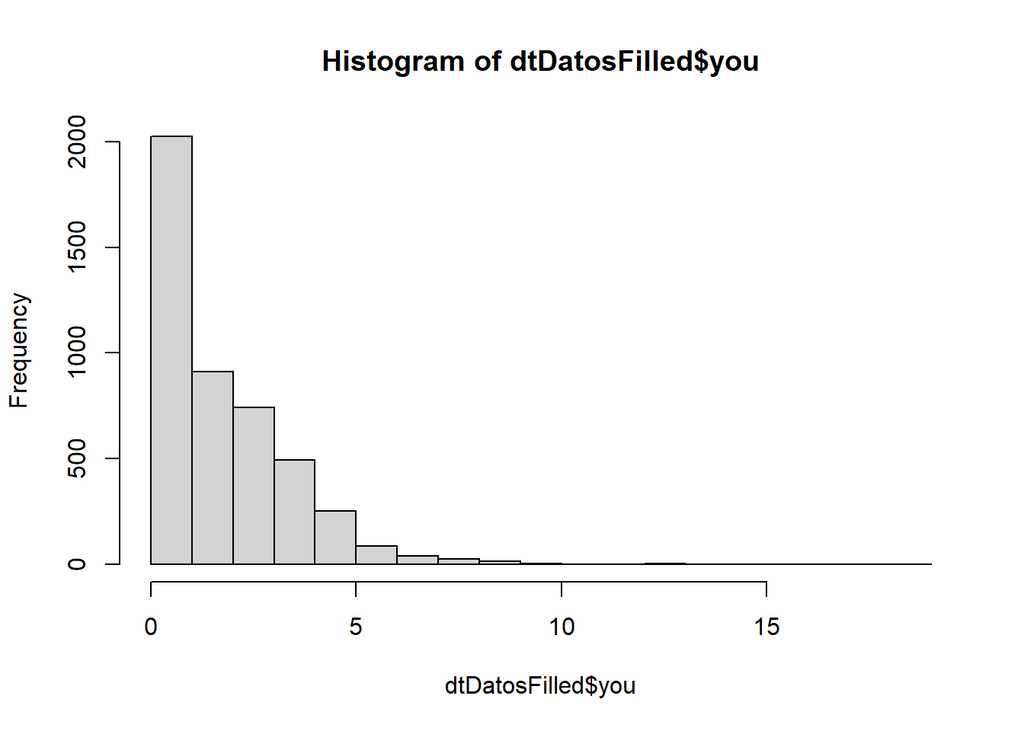

```r
  hist(dtDatosFilled$you)
```

```r
  shapiro.test(dtDatosFilled$you)
```

```
##
##  Shapiro-Wilk normality test
##
## data:  dtDatosFilled$you
## W = 0.84871, p-value < 2.2e-16
```

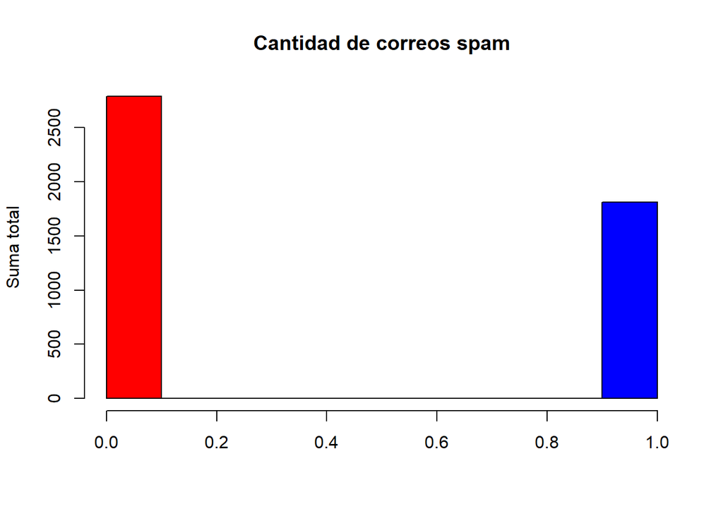

```r
  #Ninguna de ellas sigue una distribucion normal. La más cerca de hacerlo es la variable 'you'

  #Correos spam o no spam
  hist(dtDatosFilled$clase,main="Cantidad de correos spam",
       col= c("red","blue"),
       ylab="Suma total",
       xlab="")
```

```r
  p<-table(dtDatosFilled$clase)
  prop.table(p) #Porcentaje de correos si o no spam
```

```
##
##         0         1
## 0.6059552 0.3940448
```

```r
  cor(dtDatosFilled) #Comprobacion de correlacion entre variables no graficamente
```

[output not shown]

[output cut: 830 more lines]

```
## project                          -0.026016559         -0.040734726 -0.094457758
## re                               -0.051896608         -0.094955509 -0.140521777
## edu                              -0.033482220         -0.047228539 -0.146428391
## table                            -0.010433038          0.004764208 -0.045310382
## conference                       -0.017420086         -0.009198518 -0.084815832
## ;                                 0.040869943          0.056181711 -0.058670241
## (                                 0.370911748          0.113305181 -0.089811987
## [                                -0.014086578          0.006475640 -0.065326471
## !                                 0.077129257          0.036337547  0.240493784
## $                                 0.182198800          0.199664399  0.326551149
## #                                 0.062313868          0.041750538  0.065355376
## cap_run_length_average            0.492017556          0.162034524  0.110093155
## cap_run_length_longest            1.000000000          0.469014665  0.216258312
## cap_run_length_total              0.469014665          1.000000000  0.248171970
## clase                             0.216258312          0.248171970  1.000000000
```